# Project 1 GR5243 Data blog

Binglun Zhao bz2342

# Happy Moment Data blog

**From more than 100,000 happy moment messages from over 10,000 respomndents, the first thing I want to figure out is “What the hottest topics are they concerned?”. In order to find the mixture of words that is associated with each topic, I ran Latent Dirichlet allocation by using Gibbs sampling to generate 10 different topics.I chose couple of the figures to show the topics I finalized.**

```
##
##     1     2     3     4     5     6     7     8     9    10
## 16827 12150 11593 10803  5769 10893  8864  9639  7395  6453
```

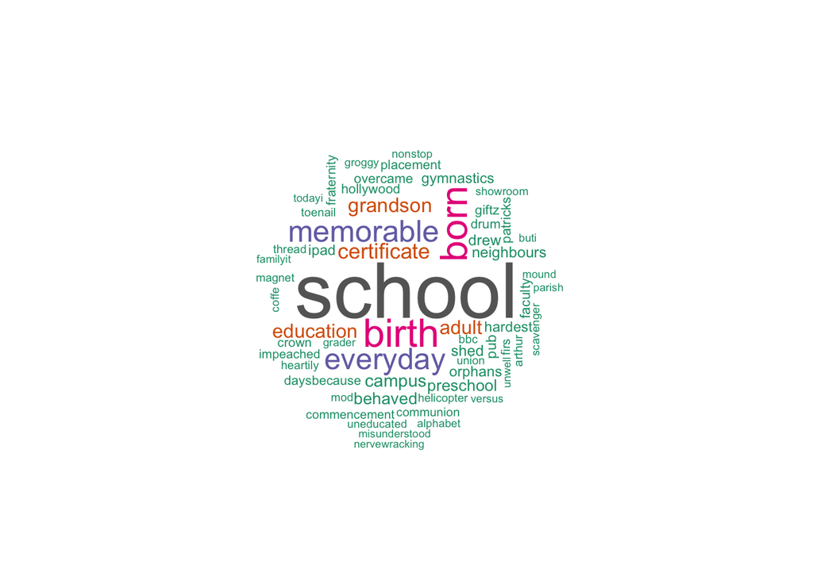

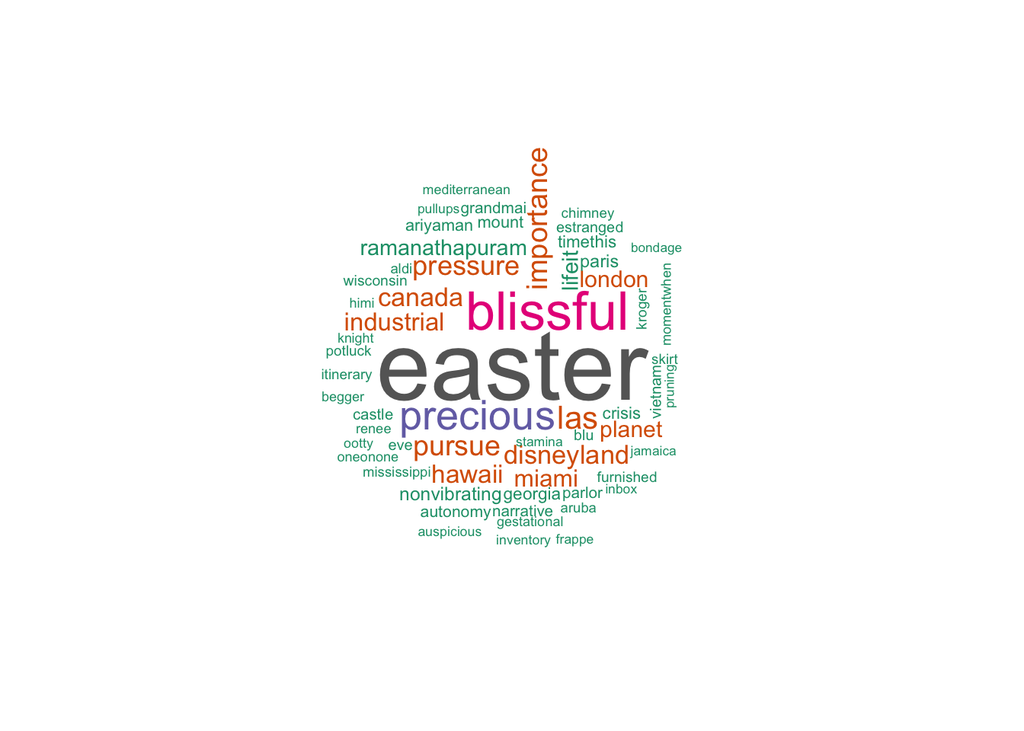

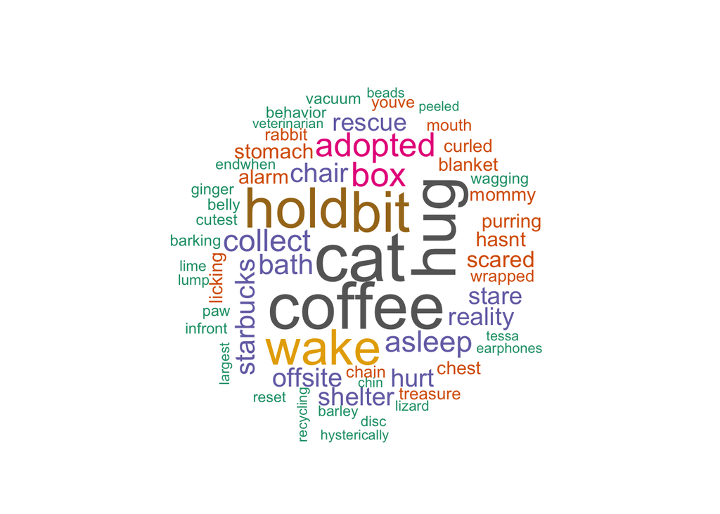

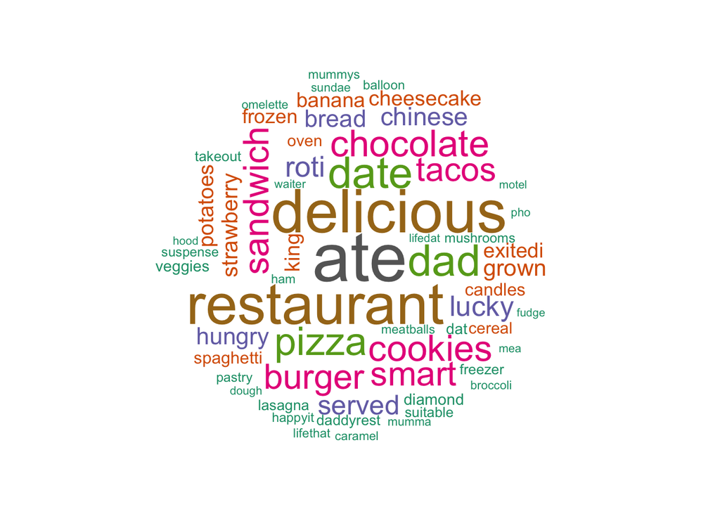

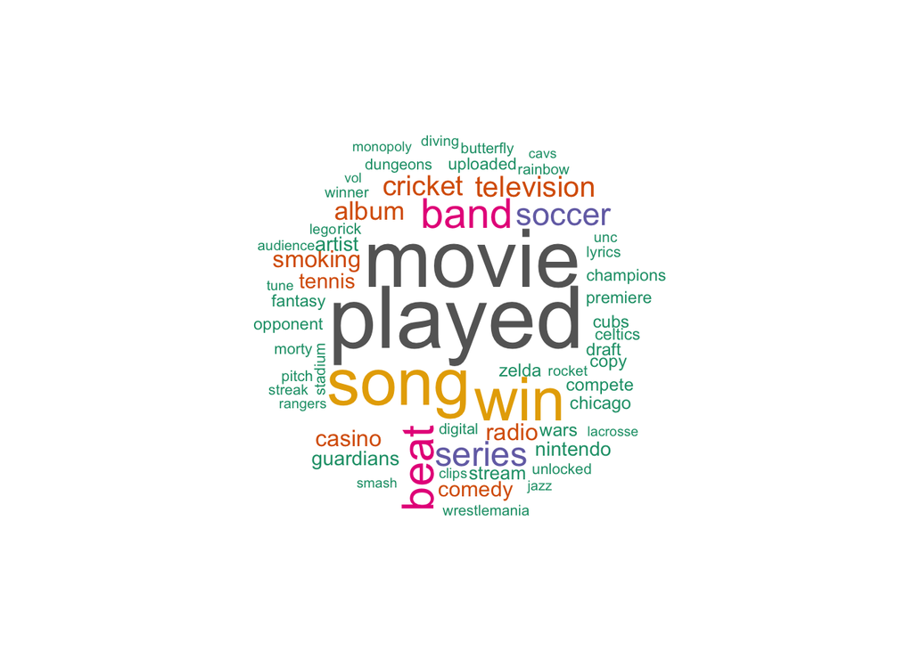

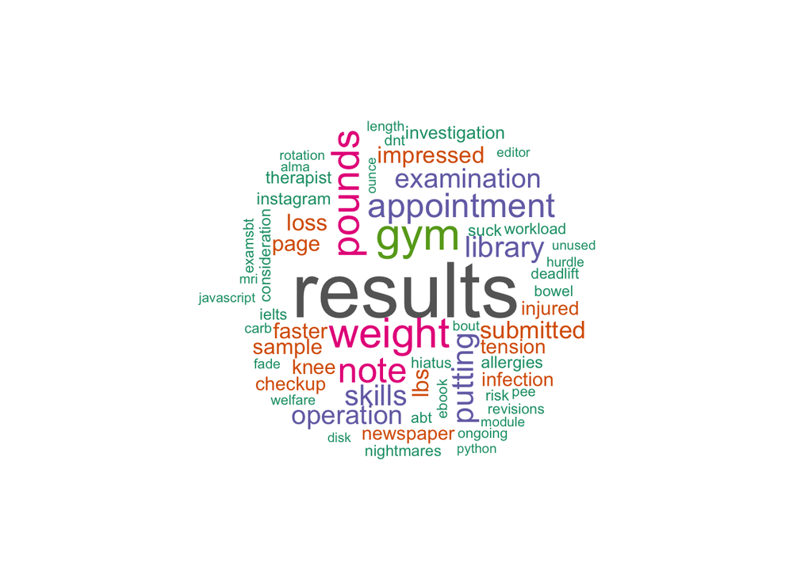

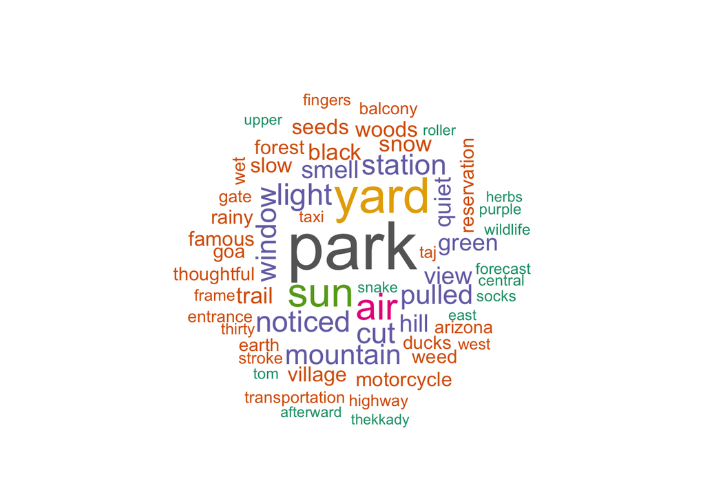

```
##       Topic 1     Topic 2      Topic 3    Topic 4   Topic 5
##  [1,] "found"     "day"        "time"     "morning" "feel"
##  [2,] "bought"    "son"        "family"   "dog"     "moment"
##  [3,] "received"  "daughter"   "enjoyed"  "night"   "life"
##  [4,] "car"       "event"      "visit"    "hours"   "happiness"
##  [5,] "money"     "school"     "house"    "love"    "people"
##  [6,] "shopping"  "told"       "home"     "home"    "makes"
##  [7,] "purchased" "college"    "day"      "cat"     "person"
##  [8,] "buy"       "class"      "spend"    "sleep"   "live"
##  [9,] "free"      "excited"    "brother"  "run"     "love"
## [10,] "store"     "mother"     "trip"     "cleaned" "positive"
## [11,] "pay"       "smile"      "weekend"  "laugh"   "experience"
## [12,] "card"      "graduation" "kids"     "couple"  "world"
## [13,] "expected"  "parents"    "spent"    "woke"    "joy"
## [14,] "online"    "child"      "planned"  "coffee"  "share"
```

[output cut: 27 more lines]

[output not shown]